# BIOS719 HW07

# About the report

This is the homework 07 of the course BIOS719.

# set environment

```r
library(tidyverse)
library(lmtest)
```

# Import data

**The data in Table 9.13 are numbers of insurance policies, n, and numbers of claims, y, for cars in various insurance categories, CAR, tabulated by age of policy holder, AGE, and district where the policy holder lived (DIST = 1, for London and other major cities, and DIST = 0, otherwise). The table is derived from the CLAIMS data set in Aitkin et al. (2005) obtained from a paper by Baxter et al. (1980)**

```r
### import the dataset
source("./data/table09_13_insurance.R")
head(dat_insurance)
```

|  | car | age | dist | y | n |
| --- | --- | --- | --- | --- | --- |
| 1 | 1 | 1 | 0 | 65 | 317 |
| 2 | 1 | 2 | 0 | 65 | 476 |
| 3 | 1 | 3 | 0 | 52 | 486 |
| 4 | 1 | 4 | 0 | 310 | 3259 |
| 5 | 2 | 1 | 0 | 98 | 486 |
| 6 | 2 | 2 | 0 | 159 | 1004 |

# Exercise 9.2 (a)

**Calculate the rate of claims y/n for each category and plot the rates by AGE, CAR and DIST to get an idea of the main effects of these factors.**

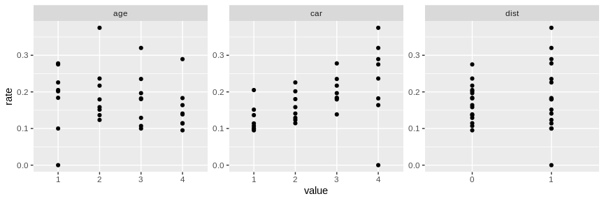

```r
gp = dat_insurance %>%
    mutate(rate = y / n) %>%
    select(rate, car, age, dist) %>%
    gather(variable, value, -rate) %>%
    mutate(value = as.character(value)) %>%
    ggplot(., aes(x = value, y = rate)) +
    geom_point() +
    facet_wrap(~variable, scales = "free")

print(gp)
```

# Exercise 9.2 (b)

**Use Poisson regression to estimate the main effects (each treated as categorical and modelled using indicator variables) and interaction terms.**

fit the Poisson regression and treat the all variable as categorical

```r
### set car and age as factor
df     = dat_insurance
df$car = factor(df$car, levels = 1:4)
df$age = factor(df$age, levels = 1:4)
### design matrix of car, age, dist and interaction terms
X = model.matrix(y ~ car * age * dist, data = df)
### model: Poisson regression
fit_full = glm(y ~ offset(log(n)) + X,
           family = poisson(link = "log"),
           data = df)
```

print out the results of the Poisson regression

```r
summary(fit_full)
```

```
Call:
glm(formula = y ~ offset(log(n)) + X, family = poisson(link = "log"),
    data = df)

Deviance Residuals:
 [1]  0  0  0  0  0  0  0  0  0  0  0  0  0  0  0  0  0  0  0  0  0  0  0  0  0  0  0  0  0  0  0  0

Coefficients: (1 not defined because of singularities)
                  Estimate Std. Error z value Pr(>|z|)
(Intercept)     -1.585e+00  1.240e-01 -12.775  < 2e-16 ***
X(Intercept)            NA         NA      NA       NA
Xcar2           -1.673e-02  1.600e-01  -0.105 0.916721
Xcar3           -1.091e-01  1.994e-01  -0.547 0.584401
Xcar4            2.935e-01  3.260e-01   0.900 0.367947
Xage2           -4.065e-01  1.754e-01  -2.317 0.020477 *
Xage3           -6.504e-01  1.860e-01  -3.496 0.000472 ***
Xage4           -7.681e-01  1.364e-01  -5.630  1.8e-08 ***
Xdist           -7.181e-01  7.179e-01  -1.000 0.317198
Xcar2:age2       1.649e-01  2.174e-01   0.759 0.448106
Xcar3:age2       5.726e-01  2.524e-01   2.269 0.023298 *
Xcar4:age2       2.556e-01  3.876e-01   0.660 0.509574
Xcar2:age3       2.049e-01  2.248e-01   0.912 0.361989
Xcar3:age3       7.173e-01  2.575e-01   2.785 0.005345 **
Xcar4:age3       2.390e-01  3.888e-01   0.615 0.538711
Xcar2:age4       2.021e-01  1.731e-01   1.168 0.242996
Xcar3:age4       4.854e-01  2.124e-01   2.286 0.022271 *
Xcar4:age4       2.505e-01  3.399e-01   0.737 0.461104
Xcar2:dist       8.312e-01  8.176e-01   1.017 0.309299
Xcar3:dist       1.131e+00  8.601e-01   1.315 0.188626
Xcar4:dist      -2.139e+01  4.225e+04  -0.001 0.999596
Xage2:dist       8.220e-01  8.548e-01   0.962 0.336246
Xage3:dist       6.504e-01  8.858e-01   0.734 0.462753
Xage4:dist       8.984e-01  7.392e-01   1.215 0.224188
Xcar2:age2:dist -1.184e+00  9.950e-01  -1.190 0.234003
Xcar3:age2:dist -1.425e+00  1.052e+00  -1.354 0.175588
Xcar4:age2:dist  2.175e+01  4.225e+04   0.001 0.999589
Xcar2:age3:dist -4.298e-01  9.944e-01  -0.432 0.665567
Xcar3:age3:dist -8.832e-01  1.039e+00  -0.850 0.395125
Xcar4:age3:dist  2.202e+01  4.225e+04   0.001 0.999584
Xcar2:age4:dist -8.042e-01  8.428e-01  -0.954 0.340026
Xcar3:age4:dist -1.032e+00  8.881e-01  -1.162 0.245079
Xcar4:age4:dist  2.178e+01  4.225e+04   0.001 0.999589
---
Signif. codes:  0 ‘***’ 0.001 ‘**’ 0.01 ‘*’ 0.05 ‘.’ 0.1 ‘ ’ 1

(Dispersion parameter for poisson family taken to be 1)

    Null deviance: 2.0783e+02  on 31  degrees of freedom
Residual deviance: 4.1230e-10  on  0  degrees of freedom
AIC: 232.36

Number of Fisher Scoring iterations: 20
```

### perform walds test to test pairwise and ternary interactions

walds test statistics: under the null, the quadratic form of $\beta$ follows chi-square distribution with the degree of the number of coefficient tests.

$$[\hat{\beta} - \beta]^T \text{cov}(\hat{\beta}) [\hat{\beta} - \beta] \sim \chi^2(p)$$

here I am going to test if $\beta = 0$

```r
### get the estimate and variance of coefficient
beta_est = coef(fit_full)
beta_cov = summary(fit_full)$cov.unscaled
```

1. **Test the interaction between car vs age:** The results of p-value do not support the interactions between car and age under 0.05 level

```r
### get the index
idx = c(
    "Xcar2:age2", "Xcar3:age2", "Xcar4:age2",
    "Xcar2:age3", "Xcar3:age3", "Xcar4:age3",
    "Xcar2:age4", "Xcar3:age4", "Xcar4:age4")
### get the coefficient and covariance of coef
b_est = as.matrix(beta_est[idx], ncol = 1)
b_cov = beta_cov[idx, idx]
### calculate the wald's statistic
p = length(idx)
wald = (t(b_est) %*% b_cov %*% b_est) %>% as.numeric
### output the resutls
cat("",
    "Wald's statistic:  ", wald, "\n",
    "Degree of freedom: ", p, "\n",
    "p value:           ", 1 - pchisq(wald, df = p))
```

```
 Wald's statistic:   0.3329449
 Degree of freedom:  9
 p value:            0.9999948
```

2. **Test the interaction between car vs dist:** The results of p-value support the interactions between car and dist under 0.05 level

```r
### get the index
idx = c("Xcar2:dist", "Xcar3:dist", "Xcar4:dist")
### get the coefficient and covariance of coef
b_est = as.matrix(beta_est[idx], ncol = 1)
b_cov = beta_cov[idx, idx]
### calculate the wald's statistic
p = length(idx)
wald = (t(b_est) %*% b_cov %*% b_est) %>% as.numeric
### output the resutls
cat("",
    "Wald's statistic:  ", wald, "\n",
    "Degree of freedom: ", p, "\n",
    "p value:           ", 1 - pchisq(wald, df = p))
```

```
 Wald's statistic:   816777426611
 Degree of freedom:  3
 p value:            0
```

3. **Test the interaction between age vs dist:** The results of p-value do not support the interactions between age and dist under 0.05 level

```r
### get the index
idx = c("Xage2:dist", "Xage3:dist", "Xage4:dist")
### get the coefficient and covariance of coef
b_est = as.matrix(beta_est[idx], ncol = 1)
b_cov = beta_cov[idx, idx]
### calculate the wald's statistic
p = length(idx)
wald = (t(b_est) %*% b_cov %*% b_est) %>% as.numeric
### output the resutls
cat("",
    "Wald's statistic:  ", wald, "\n",
    "Degree of freedom: ", p, "\n",
    "p value:           ", 1 - pchisq(wald, df = p))
```

```
 Wald's statistic:   3.18162
 Degree of freedom:  3
 p value:            0.3644617
```

4. **Test the interaction between car vs age vs dist:** The results of p-value support the interactions between car vs age vs dist under 0.05 level

```r
### get the test terms
idx = c(
    "Xcar2:age2:dist", "Xcar3:age2:dist", "Xcar4:age2:dist",
    "Xcar2:age3:dist", "Xcar3:age3:dist", "Xcar4:age3:dist",
    "Xcar2:age4:dist", "Xcar3:age4:dist", "Xcar4:age4:dist")
### get the coefficient and covariance of coef
b_est = as.matrix(beta_est[idx], ncol = 1)
b_cov = beta_cov[idx, idx]
### calculate the wald's statistic
p = length(idx)
wald = (t(b_est) %*% b_cov %*% b_est) %>% as.numeric
### output the resutls
cat("",
    "Wald's statistic:  ", wald, "\n",
    "Degree of freedom: ", p, "\n",
    "p value:           ", 1 - pchisq(wald, df = p))
```

```
 Wald's statistic:   7.669644e+12
 Degree of freedom:  9
 p value:            0
```

```r
### set car and age as factor
df     = dat_insurance
df$car = factor(df$car, levels = 1:4)
df$age = factor(df$age, levels = 1:4)
### design matrix of car, age, dist and interaction terms
X = model.matrix(y ~ car * age + car * dist + car:age:dist, data = df)
### model: Poisson regression
fit_sub = glm(y ~ offset(log(n)) + X,
              family = poisson(link = "log"),
              data = df)
```

```r
summary(fit_sub)
```

```
Call:
glm(formula = y ~ offset(log(n)) + X, family = poisson(link = "log"),
    data = df)

Deviance Residuals:
 [1]  0  0  0  0  0  0  0  0  0  0  0  0  0  0  0  0  0  0  0  0  0  0  0  0  0  0  0  0  0  0  0  0

Coefficients: (1 not defined because of singularities)
                  Estimate Std. Error z value Pr(>|z|)
(Intercept)     -1.585e+00  1.240e-01 -12.775  < 2e-16 ***
X(Intercept)            NA         NA      NA       NA
Xcar2           -1.673e-02  1.600e-01  -0.105 0.916721
Xcar3           -1.091e-01  1.994e-01  -0.547 0.584401
Xcar4            2.935e-01  3.260e-01   0.900 0.367947
Xage2           -4.065e-01  1.754e-01  -2.317 0.020477 *
Xage3           -6.504e-01  1.860e-01  -3.496 0.000472 ***
Xage4           -7.681e-01  1.364e-01  -5.630  1.8e-08 ***
Xdist           -7.181e-01  7.179e-01  -1.000 0.317198
Xcar2:age2       1.649e-01  2.174e-01   0.759 0.448106
Xcar3:age2       5.726e-01  2.524e-01   2.269 0.023298 *
Xcar4:age2       2.556e-01  3.876e-01   0.660 0.509574
Xcar2:age3       2.049e-01  2.248e-01   0.912 0.361989
Xcar3:age3       7.173e-01  2.575e-01   2.785 0.005345 **
Xcar4:age3       2.390e-01  3.888e-01   0.615 0.538711
Xcar2:age4       2.021e-01  1.731e-01   1.168 0.242996
Xcar3:age4       4.854e-01  2.124e-01   2.286 0.022271 *
Xcar4:age4       2.505e-01  3.399e-01   0.737 0.461104
Xcar2:dist       8.312e-01  8.176e-01   1.017 0.309299
Xcar3:dist       1.131e+00  8.601e-01   1.315 0.188626
Xcar4:dist      -2.139e+01  4.225e+04  -0.001 0.999596
Xcar1:age2:dist  8.220e-01  8.548e-01   0.962 0.336246
Xcar2:age2:dist -3.622e-01  5.093e-01  -0.711 0.476965
Xcar3:age2:dist -6.028e-01  6.130e-01  -0.983 0.325466
Xcar4:age2:dist  2.257e+01  4.225e+04   0.001 0.999574
Xcar1:age3:dist  6.504e-01  8.858e-01   0.734 0.462753
Xcar2:age3:dist  2.206e-01  4.519e-01   0.488 0.625406
Xcar3:age3:dist -2.328e-01  5.424e-01  -0.429 0.667797
Xcar4:age3:dist  2.267e+01  4.225e+04   0.001 0.999572
Xcar1:age4:dist  8.984e-01  7.392e-01   1.215 0.224188
Xcar2:age4:dist  9.428e-02  4.050e-01   0.233 0.815918
Xcar3:age4:dist -1.339e-01  4.923e-01  -0.272 0.785660
Xcar4:age4:dist  2.268e+01  4.225e+04   0.001 0.999572
---
Signif. codes:  0 ‘***’ 0.001 ‘**’ 0.01 ‘*’ 0.05 ‘.’ 0.1 ‘ ’ 1

(Dispersion parameter for poisson family taken to be 1)

    Null deviance: 2.0783e+02  on 31  degrees of freedom
Residual deviance: 4.1224e-10  on  0  degrees of freedom
AIC: 232.36

Number of Fisher Scoring iterations: 20
```

# Exercise 9.2 (c)

**Based on the modelling in (b), Aitkin et al. (2005) determined that all the interactions were unimportant and decided that AGE and CAR could be treated as though they were continuous variables. Fit a model incorporating these features and compare it with the best model obtained in (b). What conclusions do you reach?**

fit the model without interactions and treat variables as continuous variable

```r
fit2 = glm(y ~ offset(log(n)) + age + car + dist,
           family = poisson(link = "log"),
           data = dat_insurance)
```

print out the results of the Poisson regression

```r
summary(fit2)
```

```
Call:
glm(formula = y ~ offset(log(n)) + age + car + dist, family = poisson(link = "log"),
    data = dat_insurance)

Deviance Residuals:
    Min       1Q   Median       3Q      Max
-1.7248  -0.5681  -0.1679   0.3384   1.9126

Coefficients:
            Estimate Std. Error z value Pr(>|z|)
(Intercept) -1.85253    0.07990 -23.185  < 2e-16 ***
age         -0.17674    0.01849  -9.559  < 2e-16 ***
car          0.19777    0.02080   9.507  < 2e-16 ***
dist         0.21865    0.05853   3.736 0.000187 ***
---
Signif. codes:  0 ‘***’ 0.001 ‘**’ 0.01 ‘*’ 0.05 ‘.’ 0.1 ‘ ’ 1

(Dispersion parameter for poisson family taken to be 1)

    Null deviance: 207.833  on 31  degrees of freedom
Residual deviance:  24.685  on 28  degrees of freedom
AIC: 201.05

Number of Fisher Scoring iterations: 4
```

compare with what the model acquired in the previous problem

```r
fit_sub
```

```
Call:  glm(formula = y ~ offset(log(n)) + X, family = poisson(link = "log"),
    data = df)

Coefficients:
    (Intercept)     X(Intercept)            Xcar2            Xcar3            Xcar4            Xage2
       -1.58451               NA         -0.01673         -0.10909          0.29353         -0.40652
          Xage3            Xage4            Xdist       Xcar2:age2       Xcar3:age2       Xcar4:age2
       -0.65045         -0.76809         -0.71807          0.16491          0.57257          0.25564
     Xcar2:age3       Xcar3:age3       Xcar4:age3       Xcar2:age4       Xcar3:age4       Xcar4:age4
        0.20492          0.71725          0.23902          0.20207          0.48540          0.25049
     Xcar2:dist       Xcar3:dist       Xcar4:dist  Xcar1:age2:dist  Xcar2:age2:dist  Xcar3:age2:dist
        0.83123          1.13074        -21.39214          0.82203         -0.36219         -0.60278
Xcar4:age2:dist  Xcar1:age3:dist  Xcar2:age3:dist  Xcar3:age3:dist  Xcar4:age3:dist  Xcar1:age4:dist
       22.57125          0.65045          0.22063         -0.23278         22.67319          0.89845
Xcar2:age4:dist  Xcar3:age4:dist  Xcar4:age4:dist
        0.09428         -0.13388         22.67911

Degrees of Freedom: 31 Total (i.e. Null);  0 Residual
Null Deviance:      207.8
Residual Deviance: 4.122e-10    AIC: 232.4
```

```r
fit2
```

```
Call:  glm(formula = y ~ offset(log(n)) + age + car + dist, family = poisson(link = "log"),
    data = dat_insurance)

Coefficients:
(Intercept)          age          car         dist
    -1.8525      -0.1767       0.1978       0.2186

Degrees of Freedom: 31 Total (i.e. Null);  28 Residual
Null Deviance:      207.8
Residual Deviance: 24.69    AIC: 201
```

Since this two model are nested, we can perform likelihood ratio test. The results of the test is not significant under 0.05 level. This shows that the model in (b) does not significantly perform very well when comparing to the model fit in question 9.2 (c).

```r
lrtest(fit_sub, fit2)
```

```
Likelihood ratio test

Model 1: y ~ offset(log(n)) + X
Model 2: y ~ offset(log(n)) + age + car + dist
  #Df  LogLik  Df  Chisq Pr(>Chisq)
1  32 -84.180
2   4 -96.523 -28 24.685     0.6449
```

# In addition (d)

**Interpret the estimated coefficients of the model in (c) in terms of rate ratios**

The exponential of coefficients are the rate ratio of the change in a unit of each variable by fixing other variables

```r
round(exp(fit2$coefficients[-1]), 2)
```

```
 age  car dist
0.84 1.22 1.24
```

Intepretation:

- by fixing other covariates, the rate of events y become 0.84 times lower as age increase by one unit
- by fixing other covariates, the rate of events y become 1.22 times higher as car increase by one unit
- by fixing other covariates, the rate of events y become 1.24 times higher as dist increase by one unit